# Final Project

## Exploratory Data Analysis (EDA)

```python
votes_by_year = df_clean.groupby('year')['totalvotes'].sum().reset_index()  # this function allows me to categorize the different data in the columns
print('This is the total amount of votes per year:')
votes_by_year
```

```
This is the total amount of votes per year:
```

|  | year | totalvotes |
| --- | --- | --- |
| 0 | 1976-01-01 | 605944064 |
| 1 | 1980-01-01 | 663902096 |
| 2 | 1984-01-01 | 609936856 |
| 3 | 1988-01-01 | 537099170 |
| 4 | 1992-01-01 | 770486377 |
| 5 | 1996-01-01 | 728343795 |
| 6 | 2000-01-01 | 783441739 |
| 7 | 2004-01-01 | 768259747 |
| 8 | 2008-01-01 | 992684830 |
| 9 | 2012-01-01 | 879479158 |
| 10 | 2016-01-01 | 941573717 |
| 11 | 2020-01-01 | 1856741191 |

```python
common_office = df_clean['office'].value_counts().reset_index()
common_office.columns = ['office', 'count']
print('The most commonly contested office:')
common_office
```

```
The most commonly contested office:
```

|  | office | count |
| --- | --- | --- |
| 0 | US PRESIDENT | 4284 |

```python
state_votes = df_clean.groupby('state')['totalvotes'].sum().sort_values(ascending=False).reset_index()
print('Total State Votes (highest to lowest:')
state_votes
```

```
Total State Votes (highest to lowest:
```

|  | state | totalvotes |
| --- | --- | --- |
| 0 | NEW YORK | 1053200842 |
| 1 | CALIFORNIA | 1007277369 |
| 2 | FLORIDA | 685246872 |
| 3 | TEXAS | 506307322 |
| 4 | ILLINOIS | 500075631 |
| 5 | OHIO | 440030371 |
| 6 | MICHIGAN | 398157907 |
| 7 | PENNSYLVANIA | 361757761 |
| 8 | NEW JERSEY | 357333048 |
| 9 | COLORADO | 324033482 |
| 10 | MINNESOTA | 316582635 |
| 11 | WISCONSIN | 266188739 |
| 12 | WASHINGTON | 262813281 |
| 13 | MASSACHUSETTS | 246852975 |
| 14 | MARYLAND | 212160659 |
| 15 | GEORGIA | 210805901 |
| 16 | NORTH CAROLINA | 200677399 |
| 17 | VIRGINIA | 192521289 |
| 18 | LOUISIANA | 186432197 |
| 19 | INDIANA | 175718876 |
| 20 | IOWA | 175378878 |
| 21 | TENNESSEE | 163066425 |
| 22 | MISSOURI | 161477941 |
| 23 | KENTUCKY | 151861835 |
| 24 | ARIZONA | 140080325 |
| 25 | CONNECTICUT | 118547491 |
| 26 | OREGON | 117429704 |
| 27 | ALABAMA | 110489701 |
| 28 | SOUTH CAROLINA | 103678833 |
| 29 | UTAH | 97465303 |
| 30 | ARKANSAS | 88670493 |
| 31 | MISSISSIPPI | 85208015 |
| 32 | KANSAS | 71464299 |
| 33 | NEW HAMPSHIRE | 54573763 |
| 34 | NEW MEXICO | 53913530 |
| 35 | OKLAHOMA | 53897713 |
| 36 | NEVADA | 50006010 |
| 37 | MAINE | 48919346 |
| 38 | NEBRASKA | 46507352 |
| 39 | IDAHO | 42699871 |
| 40 | RHODE ISLAND | 41102763 |
| 41 | WEST VIRGINIA | 38063814 |
| 42 | VERMONT | 35529222 |
| 43 | DELAWARE | 30246893 |
| 44 | HAWAII | 29540989 |
| 45 | MONTANA | 25810758 |
| 46 | NORTH DAKOTA | 24682593 |
| 47 | ALASKA | 20874476 |
| 48 | DISTRICT OF COLUMBIA | 20009232 |
| 49 | SOUTH DAKOTA | 17964674 |
| 50 | WYOMING | 14555942 |

```python
votes_by_candidate = df_clean.groupby('candidate')['candidatevotes'].sum().reset_index()
votes_by_candidate_sorted = votes_by_candidate.sort_values(by='candidatevotes', ascending=False)
print('Top 10 Most Voted-For Candidates')
votes_by_candidate_sorted.head(10)
```

```
Top 10 Most Voted-For Candidates
```

|  | candidate | candidatevotes |
| --- | --- | --- |
| 240 | TRUMP, DONALD J. | 137201208 |
| 185 | OBAMA, BARACK H. | 135398119 |
| 33 | BUSH, GEORGE W. | 112484454 |
| 205 | REAGAN, RONALD | 98353843 |
| 46 | CLINTON, BILL | 92356201 |
| 32 | BUSH, GEORGE H.W. | 87989969 |
| 17 | BIDEN, JOSEPH R. JR | 81268908 |
| 40 | CARTER, JIMMY | 76306787 |
| 47 | CLINTON, HILLARY | 65853581 |
| 159 | MCCAIN, JOHN | 59948283 |

```python
writein_percentage = df_clean.groupby('year').apply(
    lambda x: (x.loc[x['writein'] == True, 'candidatevotes'].sum() / x['totalvotes'].sum()) * 100
).reset_index(name='writein_percentage')
print('The percentage of total vote that were write-in:')
writein_percentage
```

```
The percentage of total vote that were write-in:
```

|  | year | writein_percentage |
| --- | --- | --- |
| 0 | 1976-01-01 | 0.002982 |
| 1 | 1980-01-01 | 0.002000 |
| 2 | 1984-01-01 | 0.000000 |
| 3 | 1988-01-01 | 0.001956 |
| 4 | 1992-01-01 | 0.002100 |
| 5 | 1996-01-01 | 0.005255 |
| 6 | 2000-01-01 | 0.005558 |
| 7 | 2004-01-01 | 0.008935 |
| 8 | 2008-01-01 | 0.011717 |
| 9 | 2012-01-01 | 0.012446 |
| 10 | 2016-01-01 | 0.076728 |
| 11 | 2020-01-01 | 0.029265 |

```python
party_votes = df_clean.groupby('party_simplified')['totalvotes'].sum().sort_values(ascending=False).reset_index()
print('Total Amount of Votes Gained By Party, Simplified (highest to lowest)')
party_votes
```

```
Total Amount of Votes Gained By Party, Simplified (highest to lowest)
```

|  | party_simplified | totalvotes |
| --- | --- | --- |
| 0 | OTHER | 6275824281 |
| 1 | DEMOCRAT | 1344886700 |
| 2 | REPUBLICAN | 1339929297 |
| 3 | LIBERTARIAN | 1177252462 |

# Storytelling

## Data Visualization and Interpretation

### Total Votes Over Time

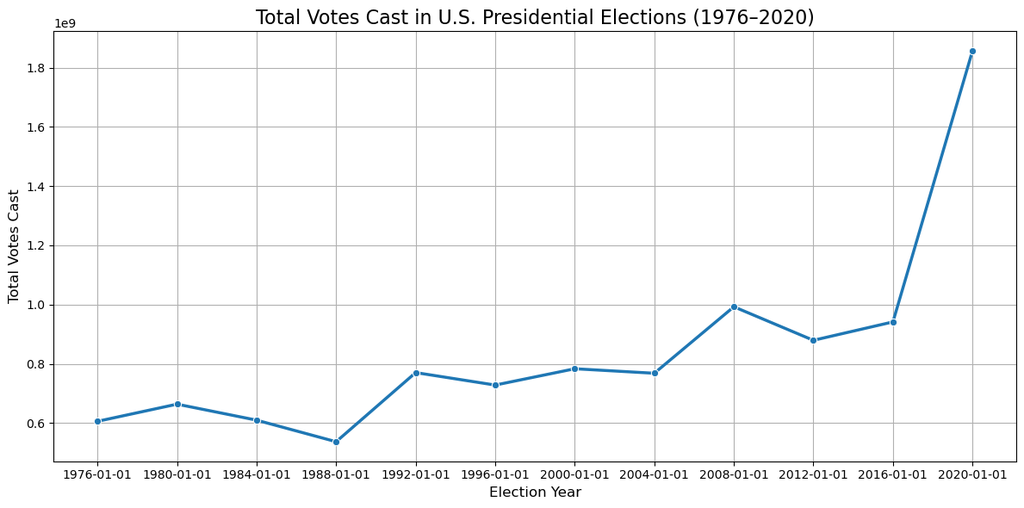

```python
votes_by_year = df_clean.groupby('year')['totalvotes'].sum().reset_index()

plt.figure(figsize=(12,6))
sns.lineplot(data=votes_by_year, x='year', y='totalvotes', marker='o', linewidth=2.5)

plt.title('Total Votes Cast in U.S. Presidential Elections (1976–2020)', fontsize=16)
plt.xlabel('Election Year', fontsize=12)
plt.ylabel('Total Votes Cast', fontsize=12)
plt.grid(True)
plt.xticks(votes_by_year['year'])
plt.tight_layout()

plt.savefig('Total Votes Over Time.png', format='png')

plt.show()
```

#### In answering the question 'How has the overall voter turnout changed over time?,' it seems that generally overtime, there is a greater voter turnout for eache election. I could associate this with the general increase in population that developed countries experience over time. There is a relativley steady decline from the 1980 and 1988 elections which may reflect attitudes toward national efficacy and political involvement. The 1992 election features a sharp increade in turnout, followed by comprable oscilations until the sharp uptick in 2008. I would attribute this to Barack Obama's election campaign, becoming the first Black person to win the race. He remained the most voted fro President until the unprecedented peak in 2020 between candidates Donald J. Trump and Joseph R. Biden. This was a highly contentious and publicized Presidential campaign, explaining the surge in votes cast.

### Correlation Between State Attributes and Total Votes

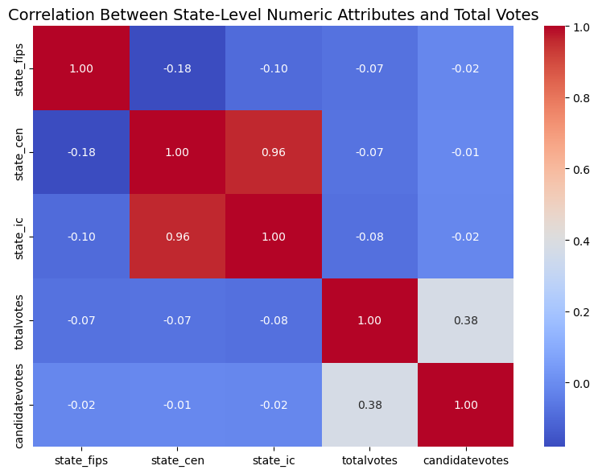

```python
num_columns = ['state_fips', 'state_cen', 'state_ic', 'totalvotes', 'candidatevotes']

corr_matrix = df_clean[num_columns].corr()

plt.figure(figsize=(8,6))
sns.heatmap(corr_matrix, annot=True, cmap='coolwarm', fmt=".2f")
plt.title('Correlation Between State-Level Numeric Attributes and Total Votes', fontsize=14)
plt.tight_layout()

plt.savefig('Correlation of Numeric Attributes.png')

plt.show()
```

#### This visualization displays the correlation between the different columns of numerical data through a heatmap. The numerical columns include the provided votes, both for each candidate and for the total Presidential election that year, as well as state identification information displayed as ‘state_ic’, ‘state_cen’, and ‘state_fips’. Given that the identification information was consistent for each state and was not a variable influenced by any other factors or values in the dataset, they had relatively low levels of correlation as seen on the visualization. Evidently, ‘state_ic’ and ‘state_cen’ share nearly identical data. The strongest correlation outside of that is between the amount of total and candidate votes. This makes sense given that the election is guided, in part, by the notion that the candidate with the most votes wins the election.

### State-wise Total Votes

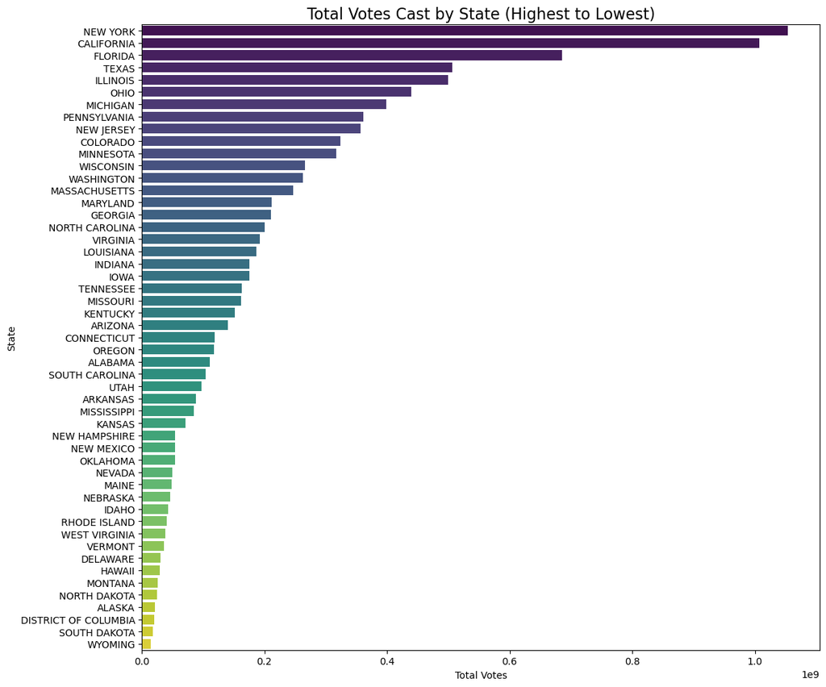

```python
state_votes = df_clean.groupby('state')['totalvotes'].sum().sort_values(ascending=False).reset_index()

plt.figure(figsize=(12,10))
sns.barplot(data=state_votes, x='totalvotes', y='state', palette='viridis')
plt.title('Total Votes Cast by State (Highest to Lowest)', fontsize=16)
plt.xlabel('Total Votes')
plt.ylabel('State')
plt.tight_layout()

plt.savefig('State-wise.png', format='png')
plt.show()
```

#### Though the general population of eligble voters is not an available part of the dataset, I would assume that the states with the largest amounts of votes cast similarly have the largest populations. I believe this is a more reasonable assumption than some states simply being more politically engaged than others. The states with the highest amoutns of casted votes also have the most electoral power in the Presidential election, a factor which is similarly decided by population above other factors like engagement. New York and California, having cast the most total votes, are some of the most populous states in the country. By contrast, Wyoming and South Dakota, having cast the least amount of total votes, are some of the least populous states.

### Party Performance Comparison

[figure not shown]

```python
party_votes = df_clean.groupby('party_simplified')['totalvotes'].sum().sort_values(ascending=False).reset_index()

plt.figure(figsize=(12,7))
sns.lineplot(data=party_performance, x='year', y='candidatevotes', hue='party_simplified', marker='o')
plt.title('Party Performance in U.S. Presidential Elections (1976–2020)', fontsize=16)
plt.xlabel('Election Year')
plt.ylabel('Total Votes Received')
plt.legend(title='Party', bbox_to_anchor=(1.05, 1), loc='upper left')
plt.grid(True)
plt.tight_layout()

plt.savefig('Party Performance Over Time.png')

plt.show()
```

#### In answering the question 'How do the total votes received by each party compare?,' it is clear primarily the impact of the two-party system which dominates United States electoral politics, especialy regarding Presidential elections. At no point in any of the elections from 1976-2020 did third-party candidates, represented in this graph as either 'LIBERTARIAN' or 'OTHER' come within the range of total votes amassed by either the Democratic or Republican Parties. As I would have assumed having studied Political Science, the winning party osciliates generally every 8 years, which is representative of two election cycles and two Presidential terms (the maximum amount an individual can serve). This implies that voters align with an individual, followed by competing parties putting more resources into their own election. Interestingly, the graph shows that the popular vote was won by the Democratic Party for the last four cycles. Obviously, Republican candidate Trump won the 2016 election, but only through the electoral college.

### Top Candidates by Total Votes

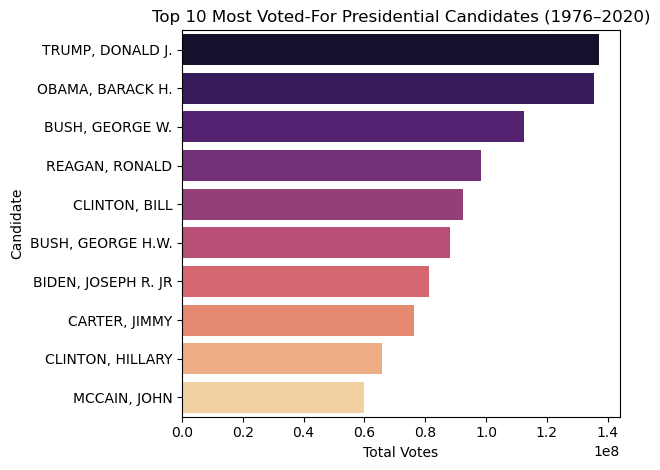

```python
sns.barplot(x='candidatevotes', y='candidate', data=votes_by_candidate_sorted.head(10), palette='magma')
plt.title('Top 10 Most Voted-For Presidential Candidates (1976–2020)')
plt.xlabel('Total Votes')
plt.ylabel('Candidate')
plt.tight_layout()

plt.savefig('Top 10 Candidates.png')

plt.show()
```

#### After recalling the analysis grouping which yielded the top 10 most-voted for candidates by using data from the 'candidatevotes' and 'candidate' columns, it is shows than the Presidential candidates from the 1976-2020 cycle whom recieved the most votes were Donald Trump, Barack Obama, George W. Bush, Ronald Reagan, Bill Clinton, George H.W. Bush, Joseph Biden, Jimmy Carter, Hillary Clinton, and John McCain. It is important to note that most of these Presidents ran two campaigns, allowing them to collect votes across two cycles. This impacts the ranking and puts candidates who only ran once at a disavdantage.

### Party Vote Percentage Share

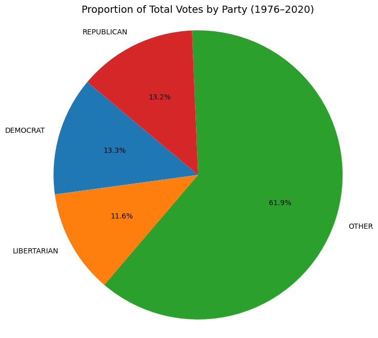

```python
party_votes = df_clean.groupby('party_simplified')['totalvotes'].sum()

plt.figure(figsize=(8,8))
plt.pie(party_votes, labels=party_votes.index, autopct='%1.1f%%', startangle=140)
plt.title('Proportion of Total Votes by Party (1976–2020)', fontsize=14)
plt.axis('equal')

plt.savefig('Votes By Party.png')

plt.show()
```

# Additional Analysis/Findings

```python
import plotly.express as px
```

```python
candidate_votes_party = (
    df_clean.groupby(['candidate', 'party_simplified'])['totalvotes']
    .sum()
    .reset_index()
)
```

```python
hundred_candidates = candidate_votes_party.sort_values(by='totalvotes', ascending=False).head(100)

fig = px.scatter(
    hundred_candidates,
    x='candidate',
    y='totalvotes',
    color='party_simplified',
    hover_name='candidate',
    title='Total Votes by Candidate and Party (1976–2020)',
    labels={'totalvotes': 'Total Votes', 'candidate': 'Candidate'},
    height=500
)

# Improve layout
fig.update_layout(
    xaxis_tickangle=45,
    xaxis={'categoryorder': 'total descending'},
    hovermode='closest',
)

fig.show()
```

[interactive chart not shown]

#### As part of my additional visualizations and analysis, I wanted to see if there were any trends between the parties that the candidates were a part of, and how this impacted the amount of votes they recieved. This visualization relies on information from the 'candidate', 'totalvotes', and 'party_simplified' columns. I decided to use a plotly scatterplot which contains the information from the top 100 most voted for Presidential candidates in the dataset. From this data, I surmised that, as represented in the 'Proportion of Total Votes by Party' pie chart visualization, most votes are amassed by third party candidates. There are some outliers in the data, represented by an 'Unknown' candidate from the same party, and President George Bush who's election served as a powerful case study against the Electoral College.

```python
state_party_votes = df_clean.groupby(['state', 'party_simplified'])['totalvotes'].sum().reset_index()
```

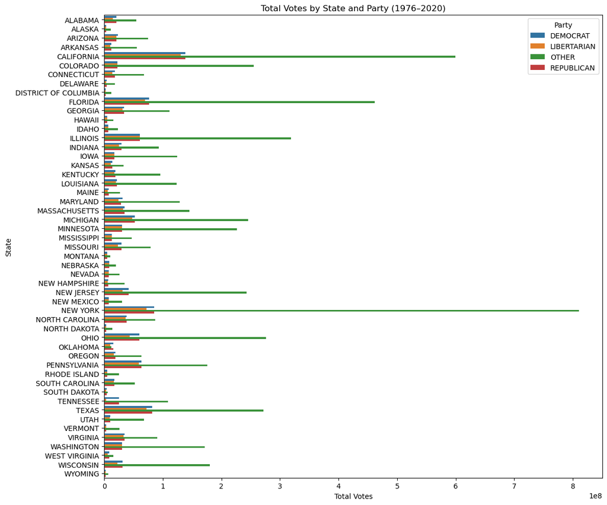

```python
plt.figure(figsize=(12, 10))

sns.barplot(
    data=state_party_votes,
    x='totalvotes',
    y='state',
    hue='party_simplified',
    orient='h'
)

plt.xlabel('Total Votes')
plt.ylabel('State')
plt.title('Total Votes by State and Party (1976–2020)')
plt.legend(title='Party')
plt.tight_layout()

plt.savefig('Votes, State, Party.png')

plt.show()
```

#### This visualization tracks the performance of different parties across states. It uses information from the 'states', 'party_simplified', and the sum of the the 'totalvotes' column. This visualization shows the voting patterns of each state, illuminating clearly which parties have the most overall success in each state regarding Presidential elections. Obvisouly, states with lower populations have lower total amounts of votes. This information can be best reflected in the 'State-wise Total Votes' visualization.